# Caso Gamma

Relatório

Silvaneo Viera dos Santos Junior

2022-10-31

## Introdução

Neste relatório apresentaremos os resultados das análises feitas sobre o GDLM k-paramétrico para o caso Gamma com parâmetro de forma e média desconhecidos. Para esta análise, vamos assumir o seguinte modelo observacional:

$$X|\phi,\mu \sim \mathcal{G}\left(\phi,\frac{\phi}{\mu}\right),$$
onde $\mathcal{G}$ representa a distribuição Gamma. Por converniência, usaremos a parametrização com $\alpha=\phi$ e $\beta=\frac{\phi}{\mu}$ de modo que:

$$X|\alpha,\beta \sim \mathcal{G}\left(\alpha,\beta\right),$$
sendo que transitar de uma parametrização para a outra é trivial e a resolução dos sistemas de compatibilização é a mesma.

Para os parâmetros $\alpha$ e $\beta$, temos que a priori conjugada é tal que:

$$\pi(\alpha,\beta) \propto \exp\left\{n_0\alpha
\ln(\beta)-k_0\ln(\Gamma(\alpha))+\theta_0\alpha-\tau_0\beta\right\},$$
onde $n_0$, $k_0$, $theta_0$ e $tau_0$ são os parâmetros da distribuição e $\Gamma$ é a função *Gamma*. Quando um par de variáveis aleatórias $X,Y$ tiver a densidade descrita acima, diremos que $X,Y \sim \Pi(n_0,k_0,\theta_0,\tau_0)$, sendo que $n_0, k_0, \tau_0>0$. No caso especial onde $n_0=k_0$, diremos que $X,Y \sim \Pi(n_0,\theta_0,\tau_0)$.

Ao obter uma amostra de tamanho $m$ do modelo observacional, a obtenção dos parâmetros da posteriori ($n_m$, $k_m$, $theta_m$ e $tau_m$) pode ser feita a partir das equações a seguir:

$$\begin{aligned}
n_m=&n_0+m\\
k_m=&k_0+m\\
\theta_m=&\theta_0+\sum_{i=1}^m\ln(x_i)\\
\tau_m=&\tau_0+\sum_{i=1}^m x_i.
\end{aligned}$$

Por último, o vetor de estatísticas suficientes associados a esta distribuição é:

$$H_p=(\alpha,\beta,\alpha \ln(\beta),\ln(\Gamma(\alpha)))'$$

Para utilizar o método proposto no artigo k-paramétrico é necessário obter $\mathbb{E}_p[{H_p}]$ e $\mathbb{E}_q[{H_p}]$, onde $E_p$ é o valor esperado calculado com $\alpha$ e $\beta$ tendo a distribuição conjugada $p$ e $E_p$ é o valor esperado calculado com $\alpha$ e $\beta$ tendo distribuição log-Normal.

Na próxima sessão discutiremos algumas propriedades da distribuição $\Pi$, pois diversos problemas encontrados tem sua origem nas características de $\Pi$.

Na sessão subsequente abordaremos os resultados da tentativa de se calcular $\mathbb{E}_p[{H_p}]$ usando aproximações de Laplace (Tierney e Kadane, 1995). Infelizmente, não conseguimos obter um bom ajuste: Mesmo com o ajuste “funcionando” o resultado da estimativa dos parâmetros está ruim.

Por último, apresentaremos uma ideia alternativa para o ajuste do modelo usando uma priori não conjugada, mas que permite uma atualização aproximada dos parâmetros. Este resultado simplifica substancialmente a compatibilização das prioris e conserva quase integralmente as propriedades da priori conjugada, em particular, o resultado da estimativa dos parâmetros também fica ruim.

## Propriedades da distribuição

Primeiro, observemos que, se $\alpha, \beta \sim \Pi\left(n_0,k_0,\theta_0,\tau_0\right)$, então:

$$\begin{aligned}
f(\beta|\alpha)&\propto \pi(\alpha,\beta)\propto\exp\left\{n_0\alpha
\ln(\beta)-k_0\ln(\Gamma(\alpha))+\theta_0\alpha-\tau_0\beta\right\}\\
& \propto \exp\left\{n_0\alpha
\ln(\beta)-\tau_0\beta\right\}=\beta^{n_0\alpha}e^{-\tau_0\beta},
\end{aligned}$$
ou seja $\beta|\alpha \sim \mathcal{G}(n_0 \alpha+1,\tau_0)$.

Usando a distribuição condicional de $\beta$ podemos reescrever $\mathbb{E}_p[H_p]=\mathbb{E}_p[\mathbb{E}_p[H_p|\alpha]]$, de onde obtemos:

$$\begin{aligned}
\mathbb{E}_p[\beta]&=\mathbb{E}_p[\mathbb{E}_p[\beta|\alpha]]=\mathbb{E}_p\left[\frac{n_0
\alpha +1}{\tau_0}\right]=\frac{n_0 \mathbb{E}_p\left[\alpha\right]
+1}{\tau_0}\\
\mathbb{E}_p[\alpha\ln(\beta)]&=\mathbb{E}_p[\alpha\mathbb{E}_p[\ln(\beta)|\alpha]]=\mathbb{E}_p\left[\alpha(\psi(n_0
\alpha +1 )-\ln(\tau_0))\right]\\
&=\mathbb{E}_p\left[\alpha\psi(n_0 \alpha +1
)\right]-\ln(\tau_0)\mathbb{E}_p\left[\alpha\right].
\end{aligned}$$
Com as equações acimas, conseguimos escrever $\mathbb{E}_p[H_p]$ como valores esperados que dependem apenas da distribuição marginal de $\alpha$, o que pode ser útil para simplicar algumas integrais e possibilitar a resolução numérica com métodos determinísticos. Vale observar que a distribuição marginal de $\alpha$ é tal que:

$$\begin{aligned}
f(\alpha)&\propto \int_0^{+\infty}\pi(\alpha,\beta) d\beta\\
&\propto \int_0^{+\infty}\exp\left\{n_0\alpha
\ln(\beta)-k_0\ln(\Gamma(\alpha))+\theta_0\alpha-\tau_0\beta\right\}d\beta\\
&=
\exp\{-k_0\ln(\Gamma(\alpha))+\theta_0\alpha\}\int_0^{+\infty}\exp\left\{n_0\alpha
\ln(\beta)-\tau_0\beta\right\}d\beta\\
&=
\exp\{-k_0\ln(\Gamma(\alpha))+\theta_0\alpha\}\int_0^{+\infty}\beta^{n_0\alpha+1-1}e^{-\tau_0\beta}d\\\
&=
\exp\{-k_0\ln(\Gamma(\alpha))+\theta_0\alpha\}\frac{\Gamma(n_0\alpha+1)}{\tau_0^{n_0\alpha+1}}\\
&=
\exp\{-k_0\ln(\Gamma(\alpha))+\theta_0\alpha+\ln(\Gamma(n_0\alpha+1))-(n_0\alpha+1)\ln(\tau_0)\}\\
&\propto
\exp\{\ln(\Gamma(n_0\alpha+1))-k_0\ln(\Gamma(\alpha))+(\theta_0-n_0\ln(\tau_0))\alpha\}\\
&=
\frac{\Gamma(n_0\alpha+1)}{\Gamma(\alpha)^{k_0}}\exp\left\{(\theta_0-n_0\ln(\tau_0))\alpha\right\}
.
\end{aligned}$$

Usando a densidade acima e aproveitando a escrita de $\mathbb{E}_p[H_p]$ como uma valor esperado em $\alpha$, podemos obter $\mathbb{E}_p[H_p]$ usando quadratura Gaussiana e, eventualmente, dispensando o uso da aproximação de Laplace.

Como discutido em outros reuniões, um pre-requisito para o uso do Teorema da Projeção é que o valor esperado de $H_p$ exista e seja finito. Caso esta condição não seja satisfeita, não podemos fazer a compatibilização das prioris normal e conjugada. Assim, devemos encontrar as condições para as quais $\Pi$ é própria (i.e., a constante de normalização de $\pi$ é finita) e o valor esperado de $H_p$ é finito. Para facilitar esta análise, podemos fazer o estudo da distribuição marginal de $\alpha$, pois se $\Pi$ é própria, $\alpha$ também será, ademais, podemos avaliar o valor esperado de $H_p$ olhando apenas para a distribuição de $\alpha$.

Adiante, vamos exibir a densidade não normalizada de $\alpha$ para vários valores de $k_0$, $n_0$, $\theta_0$ e $\tau_0$, porém, como são muitas combinações de parâmetros, a análise acaba se tornando exaustiva, por isso, antes de apresentar os gráficos, vamos resumir as conclussões:

- Se $n_0$ e $k_0$ são grandes em comparação a $\tau_0$ e $\theta_0$ a densidade de $\alpha$ se torna crescente em $\alpha$ a partir de algum valor de $\alpha$ (como conseguência, a distribuição marginal de $\alpha$ não é própria). Observe que, para uma amostra grande, temos que $n_m\approx k_m \approx m$,$\tau_m \approx n_m\sum_{i=1}^{m}x_i/m$,$\theta_m \approx k_m\sum_{i=1}^{m}\ln(x_i)/m$, assim, a observação feita neste item equivale a dizer que a média dos $x_i$’s e dos $\ln(x_i)$’s não pode ser demasiadamente pequena.
- Se $n_0\ge k_0$ a densidadde de $\alpha$ se torna crescente em $alpha$ para grande parte dos possíveis valores de $\tau_0$ e $\theta_0$.

A seguir, apresentamos a densidade marginal não normalizada de $\alpha$ para $n_0=k_0=1$ e diversos valores de $\tau_0$ e $\theta_0$:

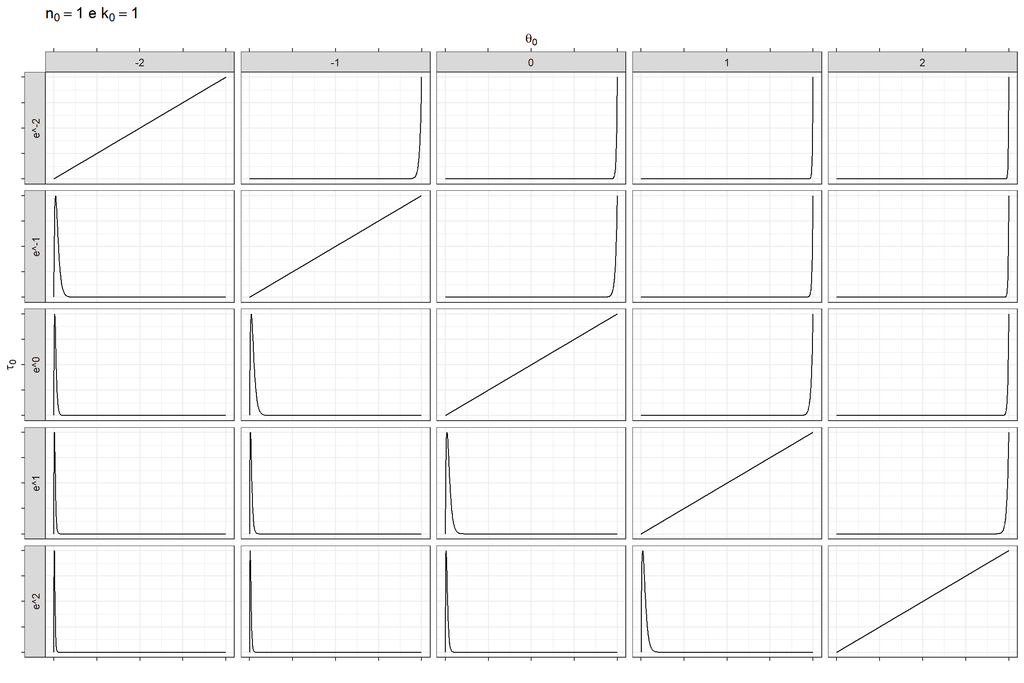

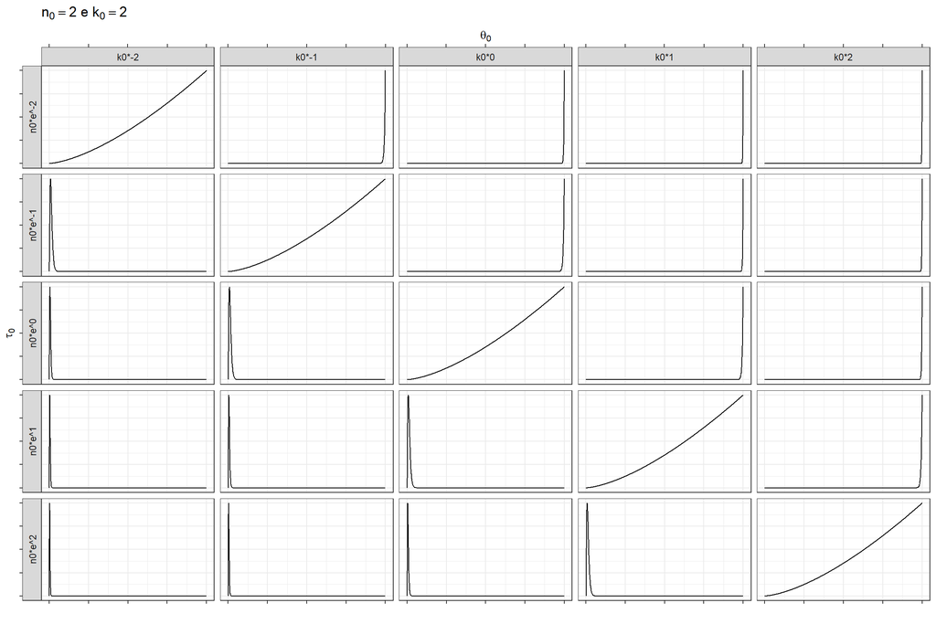

A partir das análises feitas não conseguimos encontrar uma regra que garanta que a densidade de $\alpha$ seja própria a menos que tomemos $n_0=k_0$, porém, ainda nesse caso, a restrição encontrada é inconveniente, pois a restrição $\ln\left(\frac{\tau_0}{m}\right)> \frac{\theta_0}{m}$ induz um espaço parametrico onde não há garantias de que exista um elemento que minimize a divergência KL. No geral, não tivemos problemas em encontrar o mínimo, desde que o algoritmo de Newton-Raphson seja inicializado em um local adequado, mas não conseguimos estabelecer um critério que garanta que sempre poderemos resolver o sistema.

Vale ressaltar que esses problemas estão associados a distribuição $\Pi$ e não a forma como calcularmos $\mathbb{E}_p[H_p]$, de modo que, mesmo que pudessemos calcular $\mathbb{E}_p[H_p]$ analiticamente, ainda não poderiamos ter problemas na compatibilização de prioris (claro, se conhecemos $\mathbb{E}_p[H_p]$ como uma função dos parâmetros de $\Pi$ ficaria muito mais fácil estabeler condições para que o modelo possa ser ajustado).

Dito isso, o maior problema encontrado no ajuste não está associado com a resolução do sistema, mas sim na solução encontrada que parece causar distorções no ajuste. Veremos mais sobre isso na última sessão, mas antes disso vamos descrever o método usado para calcular $\mathbb{E}_p[H_p]$ de forma aproximada (nos casos onde esse valor esperado existe).

## Método de Laplace

Suponhamos que queremos calcular $\mathbb{E}[g(x)]$ com $x$ tendo densidade proporcional a $f^*$ e $g$ sendo uma função positiva, então podemos escrever:

$$\mathbb{E}[g(x)]=\frac{\int_\mathbb{R}g(x)f^*(x)dx}{\int_\mathbb{R}f^*(x)dx}.$$

Se considerarmos que:

$$
$$\begin{aligned}
g(x)f^*(x)&\approx
\exp\left\{L_1(x^*_1)+\frac{(x-x_1^*)}{2v_1}\right\},\\
f^*(x)&\approx \exp\left\{L_2(x^*_2)+\frac{(x-x_2^*)}{2v_2}\right\},
\end{aligned}$$

$$ onde $L_1(x)=\ln(g(x)f^*(x))$, $L_2(x)=\ln(f^*(x))$, $x_i^*$ é o argumento que maximiza $L_i$ e $v_i=-L_i''^{-1}(x_i^*)$. Usando a aproximação acima, obtemos:

$$\mathbb{E}[g(x)]\approx \left(\frac{v_1}{v_2}\right)^{\frac{1}{2}}
\exp\left\{L_1(x^*_1)-L_2(x^*_2)\right\}$$

A abordagem acima pode ser facilmente generalizada para o caso onde $x$ é um vetor.

A ideia proposta pelo Migon é utilizar o método descrito para calcular $\mathbb{E}_p[H_p]$, porém encontramos um problema ao tentar por em prática esta proposta: Para calcular $\mathbb{E}_p[H_p]$ pelo método de Laplace precisamos conhecer os parâmetros da distribuição conjugada, mas desejamos calcular $\mathbb{E}[g(x)]$ justamente para encontrar os parâmetros da distribuição conjugada.

Para apresentar o problema de forma clara, vamos descrever o algoritimo de Newton-Raphson para a solução do sistema $\mathbb{E}_p[H_p]=\mathbb{E}_q[H_p]$:

- Passo 0: Suponha que conhecemos $\mathbb{E}_q[H_p]$ e seja $\phi=\mathbb{E}_{p}[H_p]'$ com $p=\Pi(n,k,\tau,\theta)$.
- Passo 1: Inicializamos escolhendo $n, k, \tau$ e $\theta$ como valores válidos.
- Passo 2: Calculamos $\phi$ e $\nabla \phi$ (a matriz de derivadas parciais de $\phi$ com relação aos parâmetro de $\Pi$). Caso não exista a forma analítica para $\nabla \phi$, devemos avaliar $\phi$ 4 vezes (além da avaliação inicial) para calcular numericamente as derivadas de $phi$.
- Passo 3: Atualizamos $n, k, \tau$ e $\theta$ segundo o algoritmo de Newton-Raphson.
- Passo 4: Se $\phi$ é suficientemente próximo de $\mathbb{E}_q[H_p]$ encerramos o algoritmo, do contrário voltamos ao passo 2.

Usando o método de Laplace para obter $\phi$, digamos, para encontrar $\mathbb{E}_p[\alpha]$, então temos que $g(\alpha,\beta)=\alpha$ e devemos encontrar $\alpha_1^*$, $\beta_1^*$, $\alpha_2^*$ e $\beta_2^*$ que maximizam $L_1$ e $L_2$, respectivamente. Infelizmente, não é possível obter uma forma analítica fechada para $\alpha_1^*$ e $\beta_1^*$, de modo que seria necessário usar o método de Newton-Raphson para encontrar esses valores, porém isto está ocorrendo dentro de **uma** avaliação de **uma** das componentes de $\phi$ para **uma** iteração do método de Newton-Raphson, ou seja, seria necessário usar o método de Newton-Raphson 20 vezes **para cada iteração** do método de Newton-Raphson principal (temos de calcular $\phi$ 5 vezes a cada iteração e em cada cálculo precisamos usar Newton-Raphson 4 vezes). Por conta disso, é inviável usar a abordagem acima para realizar a compatibilização das prioris. Se fosse possível obter $\alpha_1^*$, $\beta_1^*$ de forma analítica para todos os parâmetro, não haveria problema, porém, não sendo este o caso, se torna inviável a resolução do sistema.

Como alternativa ao método descrito acima, podemos usar o seguinte fato, se $\Pi(n,k,\theta,\tau)$ pertence à família exponencial, então:

$$\mathbb{E}_p[H_p]=\nabla
A(n,k,\theta,\tau),$$
onde $A(n,k,\theta,\tau)$ é o logarítimo da constante de normalização de $\Pi(n,k,\theta,\tau)$, isto é:

$$\exp\{A(n,k,\theta,\tau)\}=\left(\int_0^{+\infty}\int_0^{+\infty}\exp\left\{n\alpha
\ln(\beta)-k\ln(\Gamma(\alpha))+\theta\alpha-\tau\beta\right\}d\beta
d\alpha\right)^{-1}.$$

Pelo método de Laplace, temos que:

$$\exp\{A(n,k,\theta,\tau)\}\approx \sqrt{2\pi v_2}
\exp\left\{L_2(\alpha^*_2,\beta_2^*)\right\},$$
sendo que, especificamente para este caso, por sorte, há forma analítica aproximada para $\alpha^*_2$,$\beta_2^*$. De fato, veja que $L_2(\alpha,\beta)=n\alpha \ln(\beta)-k\ln(\Gamma(\alpha))+\theta\alpha-\tau\beta$, daí:

$$\begin{aligned}
\frac{\partial}{\partial \alpha}L_2(\alpha,\beta)&=n
\ln(\beta)-k\psi(\alpha)+\theta\\
\frac{\partial}{\partial
\beta}L_2(\alpha,\beta)&=n\frac{\alpha}{\beta}-\tau,
\end{aligned}$$
onde $\psi$ é a função *digamma*.

Da segunda equação obtemos que:

$$\begin{aligned}
\frac{\partial}{\partial \beta}L_2(\alpha^*,\beta^*)=0 \iff
n\frac{\alpha^*}{\beta^*}=\tau \iff \beta^*=\frac{n}{\tau}\alpha^*
\end{aligned}$$

Substitituindo o valor de $\beta^*$ na primeira equação e usando uma aproximação de primeira ordem para a função digamma obtemos que:

$$\begin{aligned}
\frac{\partial}{\partial \alpha}L_2(\alpha^*,\beta^*)&=n
\ln\left(\frac{n}{\tau}\right)+n \ln(\alpha^*)-k\psi(\alpha^*)+\theta,\\
&\approx n \ln\left(\frac{n}{\tau}\right)+n
\ln(\alpha^*)-k\ln(\alpha^*)+\frac{k}{2\alpha^*}+\theta,
\end{aligned}$$

Usando o Wolfram, encontramos que $\frac{\partial}{\partial \alpha}L_2(\alpha^*,\beta^*)=0$ se, e somente se:

$$\alpha^*=\frac{k}{2(k-n)W\left(\frac{k(2^{1-\frac{n}{k}}e^{\theta/k}\frac{n}{\tau}^{n/k})^{-k/(k-n)}}{k-n}\right)},$$
onde $W$ é a função $W$ de Lambert.

Veja que a solução proposta não está bem definida no caso $n=k$, ademais, como discutido anteriormente, a aproximação de primeira ordem para a função *digamma* deixa muito a desejar. Contudo, no caso onde $n=k$ podemos usar uma aproximação de segunda ordem para a função *digamma*, pois, neste caso, obtemos:

$$\frac{\partial}{\partial \alpha}L_2(\alpha^*,\beta^*)
\approx n \ln\left(\frac{n}{\tau}\right)+n
\ln(\alpha^*)-k\ln(\alpha^*)+\frac{k}{2\alpha^*}+\frac{k}{12\alpha^{*2}}+\theta=n
\ln\left(\frac{n}{\tau}\right)+\frac{n}{2\alpha^*}+\frac{k}{12\alpha^{*2}}+\theta,$$
daí:

Observe que, na solução acima, se $\ln\left(\frac{\tau}{n}\right)<\frac{\theta}{n}-\frac{3}{4}$, então $\alpha^*$ não está bem definido, o que é algo problemático. Dito isso, como visto anteriorimente, o ideal é que $\ln\left(\frac{\tau}{n}\right)>\frac{\theta}{n}$.

Vale destacar que, se $\Pi$ é a posteriori depois de se observar uma amostra de tamanho $m$ do modelo observacional ($m>>0$), então $\ln \left(\frac{\tau}{n}\right) \approx \ln\left(\frac{1}{m}\sum x_i\right)$ e $\theta/n \approx \frac{1}{m}\sum \ln(x_i)$, daí, como a função log é concava, vale que $\ln\left(\frac{\tau}{n}\right)>\frac{\theta}{n}$, ou seja, $\alpha^*$ está bem definido, logo, após observar uma quantidade razoável de dados, estaremos livres do risco de que $\alpha^*$ não existir.

Uma vez obtido $\alpha^*$ e $\beta^*$, podemos obter uma aproximação para $A(n,k,\theta,\tau)$ e então obter $\mathbb{E}_p[H_p]=\nabla A(n,k,\theta,\tau)$.

Como mencionado anteriormente, também podemos obter $\mathbb{E}_p[H_p]$ por integração numérica e obter um resultado semelhante. A princípio, não seria viável $\mathbb{E}_p[H_p]$ por integração numérica, pois a integral que devemos calcular é dupla, inviabilizando os métodos determinísticos que conheço (eles funcionam, mas ficam com o custo computacional irrazoável), ademais, não podemos usar integração por Monte Carlo, pois, para o método de Newton-Raphson devemos calcular as derivadas de $\mathbb{E}_p[H_p]$, como não conhecemos a forma analítica de $\mathbb{E}_p[H_p]$, devemos recorrer a deferenciação numérica, porém o erro de Monte Carlo impede que isso seja feito, o ruído aleatório intrinsico ao método de Monte Carlo “ofusca” o valor das derivadas, sendo necessário usar amostras irrazoavelmente grandes para contornar esse problema. Dito isso, durante a construção deste relatório, observamos que $\mathbb{E}_p[H_p]$ pode ser escrito como uma integral que depende apenas de $\alpha$, o que viabiliza o uso de métodos numérico determinísticos para calcular $\mathbb{E}_p[H_p]$ (especificamente, usamos Quadratura Gaussiana, que é o método *default* da função *integrate* do *R*), usando essa abordagem obtemos um resultado parecido com o resultado usando a aproximação de Laplace, porém, acredito que o uso de Quadratura Gaussiana seja mais adequado, pois evita o uso de aproximações, gerando assim valores que são numericamente iguais ao verdadeiro.

Vale destacar que, apesar da abordagem usando o método de Laplace não ser a que recomendo, acredito que o desenvolvimento dessa abordagem foi útil para dar alguns *insights* sobre o problema que não obteriamos se tivéssemos feito uso de integração numérica desde o início.

Estabelicido o método de compatibilização das prioris, prossigamos apresentando o resultado do ajuste do modelo usando a metodologia apresentada.

Para testas a qualidade do ajuste, geramos uma amostra i.i.d. com 200 elemento da distribuição $\mathcal{G}(1,1)$ e usamos a abordagem do artigo k-paramétrico para estimar os parâmetros $\alpha$ e $\beta$ da distribuição dos dados (usamos quadratura gaussiana para calcular $\mathbb{E}_p[H_p]$, Newton-Raphson para resolver o sistema $\mathbb{E}_p[H_p]=\mathbb{E}_q[H_p]$ e integração por Monte Carlo para obter a distribuição preditiva dos dados). O resultado pode ser observado a seguir:

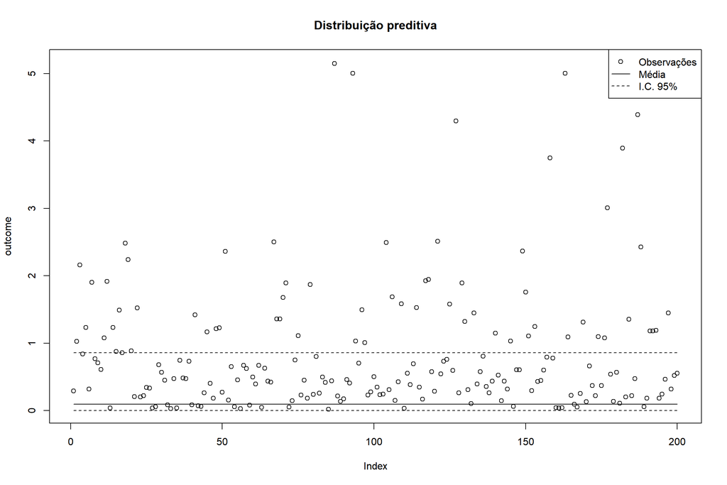

```
Parâmetro alpha
Valor real: 1
Média: 2.88434957164917
Mediana: 2.78692776437594
Quantil de 0.975: 4.719072751092
Quantil de 0.025: 1.64393150728427
```

```
Parâmetro beta
Valor real: 1
Média: 44.0971917268976
Mediana: 36.7134370523594
Quantil de 0.975: 118.859428644718
Quantil de 0.025: 11.5062125796447
```

## Proposta alternativa: Usar priori não conjugada